# Introduction to ggfunction

## Overview

**ggfunction** extends ggplot2 to visualize mathematical functions directly. It provides a unified interface organized around two families:

1. **Dimensional taxonomy** – functions classified by input/output dimension:
   - `geom_function_1d_1d()`: $\mathbb{R} \to \mathbb{R}$ (scalar to scalar)
   - `geom_function_1d_2d()`: $\mathbb{R} \to \mathbb{R}^2$ (parametric curves)
   - `geom_function_2d_1d()`: $\mathbb{R}^2 \to \mathbb{R}$ (scalar fields, raster/contour)
   - `geom_function_2d_2d()`: $\mathbb{R}^2 \to \mathbb{R}^2$ (vector fields)
2. **Probability distributions** – specialized geoms for distribution functions:
   - `geom_pdf()`: probability density function
   - `geom_cdf()`: cumulative distribution function
   - `geom_pmf()`: probability mass function (lollipop)
   - `geom_qf()`: quantile function
   - `geom_cdf_discrete()`: discrete CDF (right-continuous step function)
   - `geom_qf_discrete()`: discrete quantile function (left-continuous step function)
   - `geom_survival_discrete()`: discrete survival function $S(x) = 1 - F(x)$ (right-continuous step function)
   - `geom_survival()`: survival function $S(x) = 1 - F(x)$
   - `geom_hf()`: hazard function $h(x) = f(x)/S(x)$

## Dimensional Taxonomy

### 1D to 1D: Scalar Functions

Plot any $f: \mathbb{R} \to \mathbb{R}$ with optional interval shading:

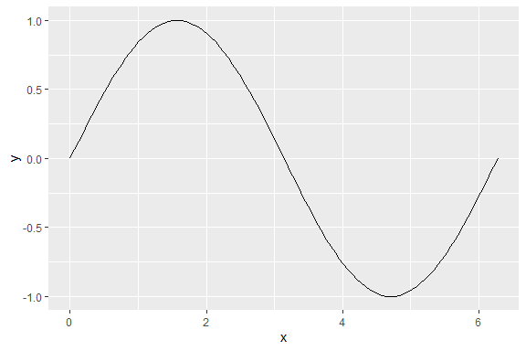

```r
ggplot() +
  geom_function_1d_1d(fun = sin, xlim = c(0, 2 * pi))
```

Shade a specific interval:

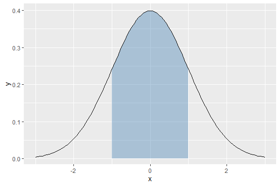

```r
ggplot() +
  geom_function_1d_1d(
    fun = dnorm, xlim = c(-3, 3),
    shade_from = -1, shade_to = 1, fill = "steelblue"
  )
```

### 1D to 2D: Parametric Curves

Map a scalar parameter to a 2D path using `tlim` to set the parameter range:

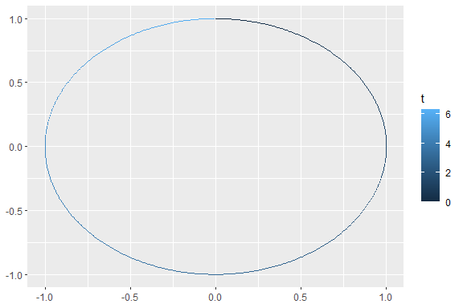

```r
f <- function(t) c(sin(t), cos(t))
ggplot() +
  geom_function_1d_2d(fun = f, tlim = c(0, 2 * pi))
```

### 2D to 1D: Scalar Fields

Visualize $f: \mathbb{R}^2 \to \mathbb{R}$ as a raster:

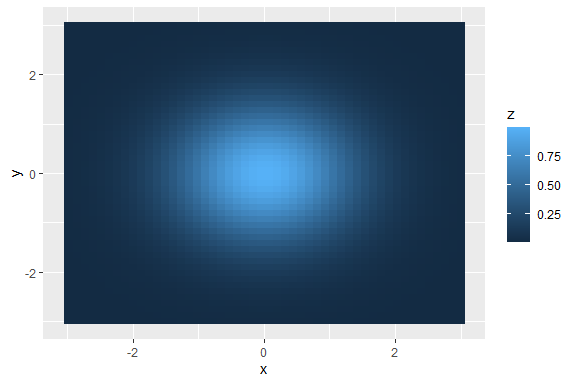

```r
f_gaussian <- function(v) exp(-(v[1]^2 + v[2]^2) / 2)

ggplot() +
  geom_function_2d_1d(fun = f_gaussian, xlim = c(-3, 3), ylim = c(-3, 3))
```

Or as contour lines:

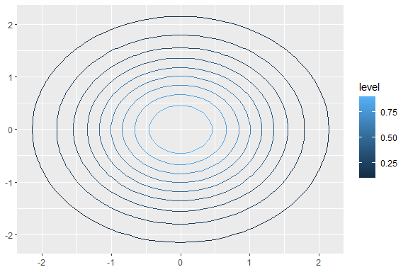

```r
ggplot() +
  geom_function_2d_1d(
    fun = f_gaussian, xlim = c(-3, 3), ylim = c(-3, 3),
    type = "contour"
  )
```

Or as filled contours:

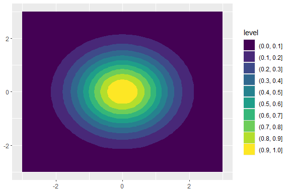

```r
ggplot() +
  geom_function_2d_1d(
    fun = f_gaussian, xlim = c(-3, 3), ylim = c(-3, 3),
    type = "contour_filled"
  )
```

### 2D to 2D: Vector Fields

Visualize vector fields as short arrows at each grid point (the default, `type = "vector"`):

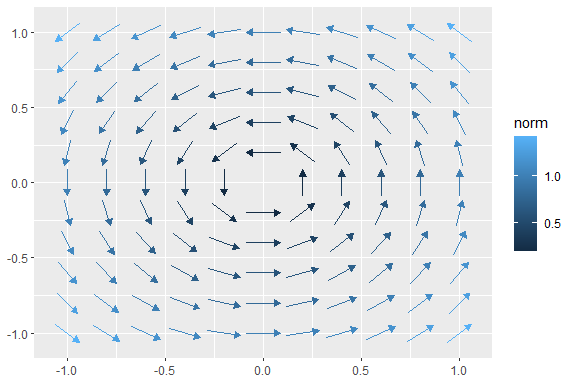

```r
f_rotation <- function(u) c(-u[2], u[1])
ggplot() +
  geom_function_2d_2d(fun = f_rotation, xlim = c(-1, 1), ylim = c(-1, 1))
```

Or as integral-curve streamlines with `type = "stream"`:

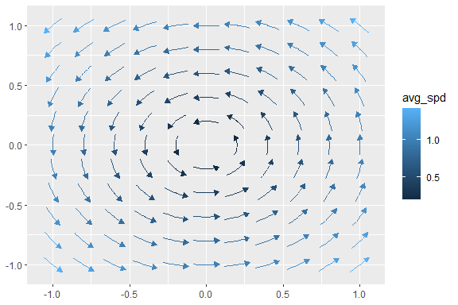

```r
ggplot() +
  geom_function_2d_2d(fun = f_rotation, xlim = c(-1, 1), ylim = c(-1, 1),
    type = "stream")
```

## Probability Distribution Family

### PDF with Shading

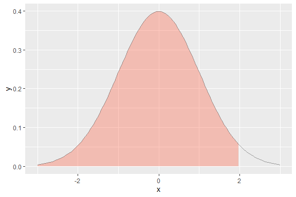

```r
ggplot() +
  geom_pdf(fun = dnorm, xlim = c(-3, 3), p = 0.975, fill = "tomato")
```

Two-sided shading (e.g., middle 95%):

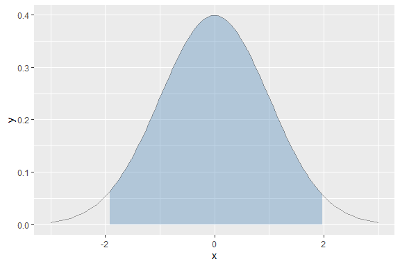

```r
ggplot() +
  geom_pdf(
    fun = dnorm, xlim = c(-3, 3),
    p_lower = 0.025, p_upper = 0.975, fill = "steelblue"
  )
```

Shade the tails instead (outside):

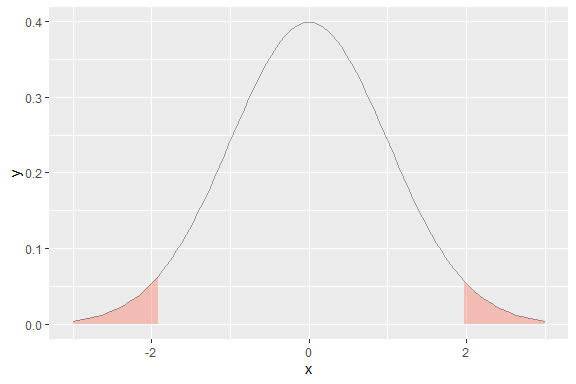

```r
ggplot() +
  geom_pdf(
    fun = dnorm, xlim = c(-3, 3),
    p_lower = 0.025, p_upper = 0.975, shade_outside = TRUE, fill = "tomato"
  )
```

### CDF

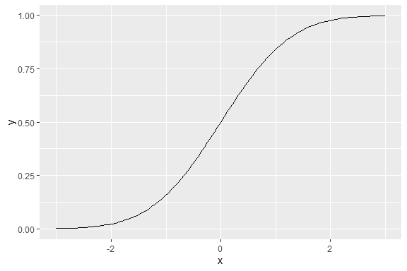

```r
ggplot() +
  geom_cdf(fun = pnorm, xlim = c(-3, 3))
```

With shading below a quantile:

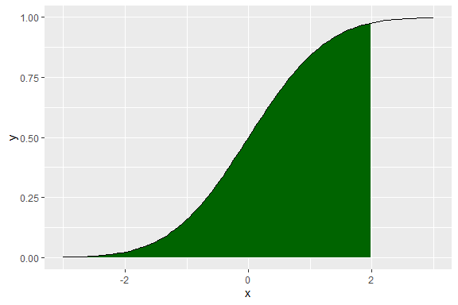

```r
ggplot() +
  geom_cdf(fun = pnorm, xlim = c(-3, 3), p = 0.975, fill = "darkgreen")
```

### PMF (Lollipop)

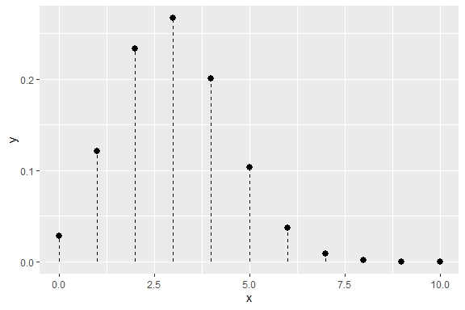

```r
ggplot() +
  geom_pmf(fun = dbinom, xlim = c(0, 10), args = list(size = 10, prob = 0.3))
```

Tail shading with `p` and HDR shading with `shade_hdr` work the same way as in `geom_pdf()`:

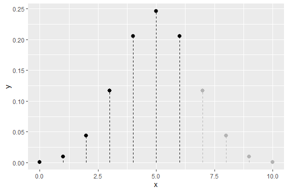

```r
ggplot() +
  geom_pmf(fun = dbinom, xlim = c(0, 10), args = list(size = 10, prob = 0.5), p = 0.8)
```

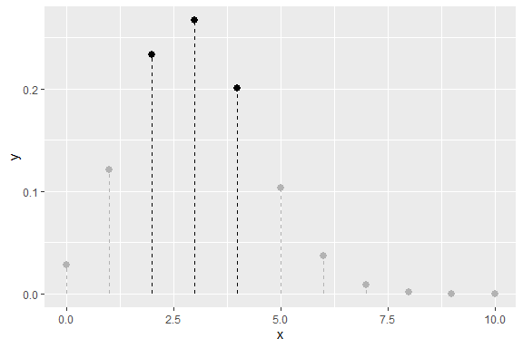

```r
ggplot() +
  geom_pmf(fun = dbinom, xlim = c(0, 10), args = list(size = 10, prob = 0.3),
    shade_hdr = 0.7)
```

### Quantile Function

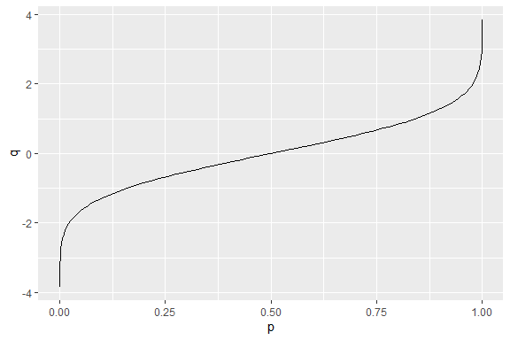

```r
ggplot() +
  geom_qf(fun = qnorm, args = list(mean = 0, sd = 1))
```

### Discrete CDF (Step Function)

`geom_cdf_discrete()` renders a discrete CDF as a right-continuous step function with dashed vertical jumps and open/closed endpoint circles:

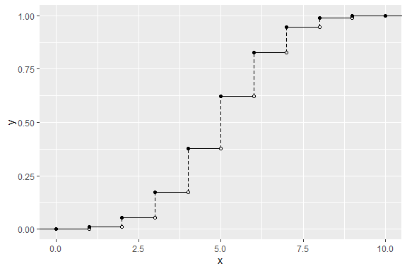

```r
ggplot() +
  geom_cdf_discrete(
    fun = dbinom, xlim = c(0, 10), args = list(size = 10, prob = 0.5)
  )
```

Use `show_points = FALSE` or `show_vert = FALSE` to suppress circles or jump lines:

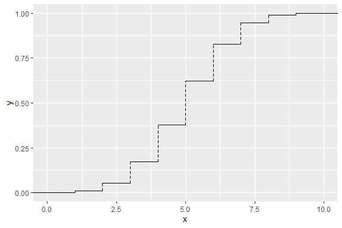

```r
ggplot() +
  geom_cdf_discrete(
    fun = dbinom, xlim = c(0, 10), args = list(size = 10, prob = 0.5),
    show_points = FALSE
  )
```

### Discrete Quantile Function (Step Function)

`geom_qf_discrete()` renders the inverse of the discrete CDF as a left-continuous step function on $[0, 1]$, with closed circles at the bottom of each jump and open circles at the top:

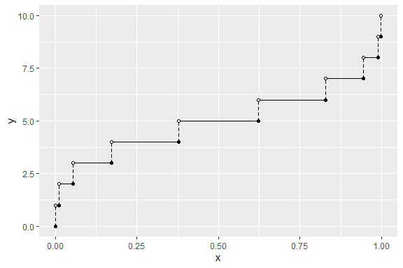

```r
ggplot() +
  geom_qf_discrete(
    fun = dbinom, xlim = c(0, 10), args = list(size = 10, prob = 0.5)
  )
```

### Discrete Survival Function (Step Function)

`geom_survival_discrete()` renders the discrete survival function $S(x) = 1 - F(x) = P(X > x)$ as a right-continuous step function with the same visual conventions as `geom_cdf_discrete()`:

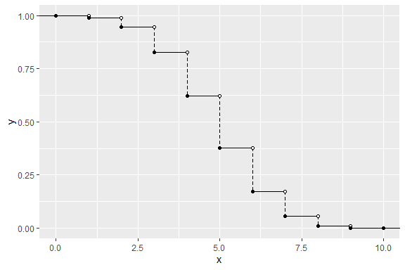

```r
ggplot() +
  geom_survival_discrete(
    fun = dbinom, xlim = c(0, 10), args = list(size = 10, prob = 0.5)
  )
```

### Survival Function

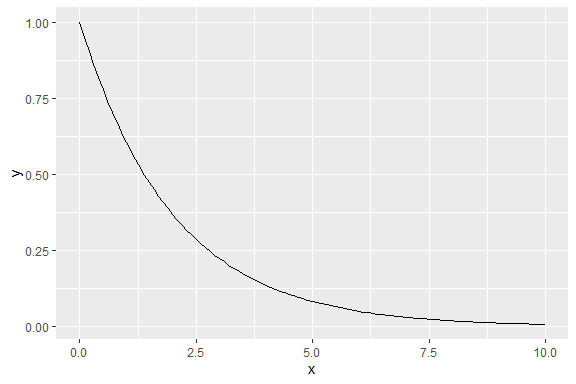

```r
ggplot() +
  geom_survival(fun = pexp, xlim = c(0, 10), args = list(rate = 0.5))
```

### Hazard Function

The exponential distribution has a constant hazard rate:

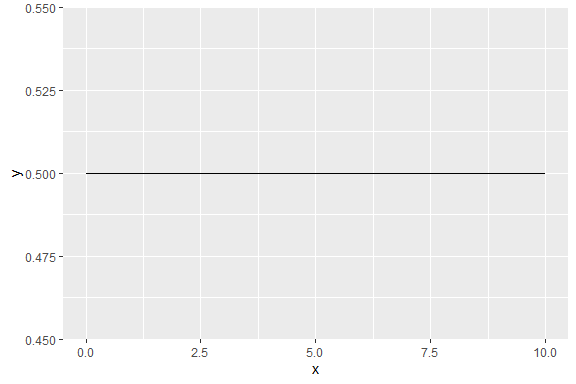

```r
ggplot() +
  geom_hf(
    pdf_fun = dexp, cdf_fun = pexp,
    xlim = c(0.01, 10), args = list(rate = 0.5)
  )
```